# exercise-09

SLCornett

3/29/2022

**Practice_Simple_Linear_Regression**

```r
#library(mosaic)
library(tidyverse)
library(broom)
library(patchwork)
library(skimr)
library(infer)
library(dplyr)
library(ggplot2)
library(lmodel2)
```

1. Using the {tidyverse} read_csv() function, load the “Street_et_al_2017.csv” dataset from this URL as a “tibble” named d.

```r
f <- "https://raw.githubusercontent.com/difiore/ada-2022-datasets/main/Street_et_al_2017.csv"
d <- read_csv(f, col_names = TRUE)
```

2. Do a quick exploratory data analysis where you generate the five-number summary (median, minimum and maximum and 1st and 3rd quartile values), plus mean and standard deviation, for each quantitative variable

```r
skim(d)
```

Data summary

| Name | d |
| --- | --- |
| Number of rows | 301 |
| Number of columns | 13 |
| _______________________ |  |
| Column type frequency: |  |
| character | 2 |
| numeric | 11 |
| ________________________ |  |
| Group variables | None |

**Variable type: character**

| skim_variable | n_missing | complete_rate | min | max | empty | n_unique | whitespace |
| --- | --- | --- | --- | --- | --- | --- | --- |
| Species | 0 | 1 | 10 | 41 | 0 | 301 | 0 |
| Taxonomic_group | 0 | 1 | 10 | 15 | 0 | 4 | 0 |

**Variable type: numeric**

| skim_variable | n_missing | complete_rate | mean | sd | p0 | p25 | p50 | p75 | p100 | hist |
| --- | --- | --- | --- | --- | --- | --- | --- | --- | --- | --- |
| Social_learning | 98 | 0.67 | 2.30 | 16.51 | 0.00 | 0.00 | 0.00 | 0.00 | 214.00 | ▇▁▁▁▁ |
| Research_effort | 115 | 0.62 | 38.76 | 80.59 | 1.00 | 6.00 | 16.00 | 37.75 | 755.00 | ▇▁▁▁▁ |
| ECV | 117 | 0.61 | 68.49 | 82.84 | 1.63 | 11.82 | 58.55 | 86.20 | 491.27 | ▇▁▁▁▁ |
| Group_size | 114 | 0.62 | 13.26 | 15.20 | 1.00 | 3.12 | 7.50 | 18.23 | 91.20 | ▇▂▁▁▁ |
| Gestation | 161 | 0.47 | 164.50 | 38.00 | 59.99 | 138.35 | 166.03 | 183.26 | 274.78 | ▁▅▇▃▁ |
| Weaning | 185 | 0.39 | 311.09 | 253.08 | 40.00 | 121.66 | 234.16 | 388.78 | 1260.81 | ▇▃▁▁▁ |
| Longevity | 181 | 0.40 | 331.97 | 165.67 | 103.00 | 216.00 | 301.20 | 393.30 | 1470.00 | ▇▂▁▁▁ |
| Sex_maturity | 194 | 0.36 | 1480.23 | 999.23 | 283.18 | 701.52 | 1427.17 | 1894.11 | 5582.93 | ▇▆▂▁▁ |
| Body_mass | 63 | 0.79 | 6795.18 | 14229.83 | 31.23 | 739.44 | 3553.50 | 7465.00 | 130000.00 | ▇▁▁▁▁ |
| Maternal_investment | 197 | 0.35 | 478.64 | 292.07 | 99.99 | 255.88 | 401.35 | 592.22 | 1492.30 | ▇▅▂▁▁ |
| Repro_lifespan | 206 | 0.32 | 9064.97 | 4601.57 | 2512.16 | 6126.22 | 8325.89 | 10716.60 | 39129.57 | ▇▃▁▁▁ |

[note to self: $\beta$ = beta letter]

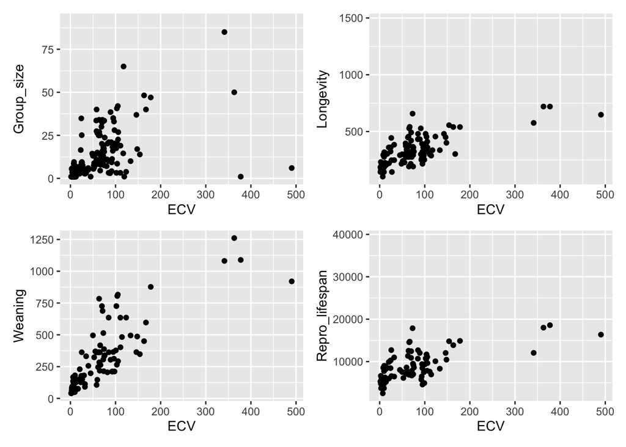

```r
# alternative method: plot(x = , y = )

# ECV by group size
gs <- ggplot(data = d, aes(x = ECV, y = Group_size))
gs <- gs + geom_point(na.rm=TRUE) # make it a scatterplot

#ECV by longevity
lg <- ggplot(data = d, aes(x = ECV, y = Longevity))
lg <- lg + geom_point(na.rm=TRUE)

#ECV by Weaning
wean <- ggplot(data = d, aes(x = ECV, y = Weaning))
wean <- wean + geom_point(na.rm = TRUE)

#ECV by Reproductive lifespan
rl <- ggplot(data = d, aes(x = ECV, y = Repro_lifespan))
rl <- rl + geom_point(na.rm = TRUE)

gs+lg+wean+rl
```

4. Derive by hand the ordinary least squares regression coefficients ($\beta1$) and ($\beta0$) for ECV as a function of social group size. [HINT: You will need to remove rows from your dataset where one of these variables is missing.]

```r
#filtered d in the block above
df <- d %>% # pinned and exclamation mark before is "not"
  filter(!is.na(ECV) & !is.na(Group_size)) # filters out all the rows that have NA in them and assigns to a new data set, df (aka d_mod)
# β1 by hand
b1 <- cor(df$ECV, df$Group_size) * sd(df$ECV)/sd(df$Group_size)
b1 # this checks out
```

```
## [1] 2.463071
```

```r
# beta0 by hand
b0 <- mean(df$ECV) - b1*mean(df$Group_size)
b0 # this checks out
```

```
## [1] 30.35652
```

5. confirm that you get the same results using the ‘lm()’ fxn.

```r
model <- lm(formula = ECV ~ Group_size, data = d) #linear model fxn smart so don't need to filter out the NAs when running this, ie can use d instead of df
model
```

```
##
## Call:
## lm(formula = ECV ~ Group_size, data = d)
##
## Coefficients:
## (Intercept)   Group_size
##      30.357        2.463
```

```r
#summary of model (could also use glace() from {infer} to get other info)
summary(model) #matches lm function output
```

```
##
## Call:
## lm(formula = ECV ~ Group_size, data = d)
##
## Residuals:
##    Min     1Q Median     3Q    Max
## -92.05 -29.25 -15.14  13.07 445.28
##
## Coefficients:
##             Estimate Std. Error t value Pr(>|t|)
## (Intercept)  30.3565     6.7963   4.467 1.56e-05 ***
## Group_size    2.4631     0.3508   7.021 7.26e-11 ***
## ---
## Signif. codes:  0 '***' 0.001 '**' 0.01 '*' 0.05 '.' 0.1 ' ' 1
##
## Residual standard error: 60.31 on 149 degrees of freedom
##   (150 observations deleted due to missingness)
## Multiple R-squared:  0.2486, Adjusted R-squared:  0.2436
## F-statistic:  49.3 on 1 and 149 DF,  p-value: 7.259e-11
```

```r
model_sum <- tidy(model)
model_sum
```

```
## # A tibble: 2 × 5
##   term        estimate std.error statistic  p.value
##   <chr>          <dbl>     <dbl>     <dbl>    <dbl>
## 1 (Intercept)    30.4      6.80       4.47 1.56e- 5
## 2 Group_size      2.46     0.351      7.02 7.26e-11
```

```r
#residuals = how far each observation deviates from the predicted line
residuals <-  df$ECV - (b0 + b1 * df$Group_size) # or residuals <- model$residuals

#num <- sum(residuals^2)/(length(residuals)-2) #only squaring Group size, not the whole things
num <- sum(residuals^2)
den <- sum((df$Group_size - mean(df$Group_size))^2) * (nrow(df) - 2)  #need to define n as the number of rows, either as a variable or as nrow(df)
```

6. Repeat the above analysis for different groups of primates (catarrhines, platyrrhines, strepsirhines (big radiation, including lemurs)) separately.These are stored in the variable *Taxonomic_group*.

```r
# Selecting by taxonomic group. i am very proud of this.
#Catarrhines
# filtering for just these dudes
catarrhines <- df %>% filter(Taxonomic_group == "Catarrhini")
# b1 by hand
cata_b1 <- cor(catarrhines$ECV, catarrhines$Group_size) * (sd(catarrhines$ECV)/sd(catarrhines$Group_size))
cata_b1
```

```
## [1] 1.265551
```

```r
# b0 by hand
cata_b0 <- mean(catarrhines$ECV) - cata_b1 * mean(catarrhines$Group_size)
cata_b0
```

```
## [1] 81.64085
```

```r
#cata lm
cata_m <- lm(formula = ECV ~ Group_size, data = catarrhines)
summary(cata_m)
```

```
##
## Call:
## lm(formula = ECV ~ Group_size, data = catarrhines)
##
## Residuals:
##    Min     1Q Median     3Q    Max
## -74.24 -32.18 -17.76   4.20 401.18
##
## Coefficients:
##             Estimate Std. Error t value Pr(>|t|)
## (Intercept)  81.6408    15.3317   5.325 1.27e-06 ***
## Group_size    1.2656     0.6192   2.044   0.0449 *
## ---
## Signif. codes:  0 '***' 0.001 '**' 0.01 '*' 0.05 '.' 0.1 ' ' 1
##
## Residual standard error: 76.4 on 67 degrees of freedom
## Multiple R-squared:  0.05869,    Adjusted R-squared:  0.04464
## F-statistic: 4.177 on 1 and 67 DF,  p-value: 0.0449
```

```r
#platyrrhines
#filtering for these dudes
platyrrhines <- df %>% filter(Taxonomic_group == "Platyrrhini")
# b1 by hand
platy_b1 <- cor(platyrrhines$ECV, platyrrhines$Group_size) * (sd(platyrrhines$ECV)/sd(platyrrhines$Group_size))
platy_b1
```

```
## [1] 1.965176
```

```r
# b0 by hand
platy_b0 <- mean(platyrrhines$ECV) - platy_b1 * mean(platyrrhines$Group_size)
platy_b0
```

```
## [1] 16.18121
```

```r
#platy lm
platy_m <- lm(formula = ECV ~ Group_size, data = platyrrhines)
summary(platy_m)
```

```
##
## Call:
## lm(formula = ECV ~ Group_size, data = platyrrhines)
##
## Residuals:
##     Min      1Q  Median      3Q     Max
## -60.528 -19.817  -3.568  19.968  72.344
##
## Coefficients:
##             Estimate Std. Error t value Pr(>|t|)
## (Intercept)  16.1812     7.3865   2.191 0.035646 *
## Group_size    1.9652     0.4554   4.315 0.000136 ***
## ---
## Signif. codes:  0 '***' 0.001 '**' 0.01 '*' 0.05 '.' 0.1 ' ' 1
##
## Residual standard error: 26.98 on 33 degrees of freedom
## Multiple R-squared:  0.3607, Adjusted R-squared:  0.3414
## F-statistic: 18.62 on 1 and 33 DF,  p-value: 0.0001364
```

```r
#strepsirhines
# filtering for these dudes
strepsirhines <- df %>% filter (Taxonomic_group == "Strepsirhini")
# b1 by hand
strep_b1 <- cor(strepsirhines$ECV, strepsirhines$Group_size) * (sd(strepsirhines$ECV)/sd(strepsirhines$Group_size))
strep_b1
```

```
## [1] 1.840664
```

```r
# b0 by hand
strep_b0 <- mean(strepsirhines$ECV) - strep_b1 * mean(strepsirhines$Group_size)
strep_b0
```

```
## [1] 8.176384
```

```r
#lm for strep
strep_m <- lm(formula = ECV ~ Group_size, data = strepsirhines)
summary(strep_m)
```

```
##
## Call:
## lm(formula = ECV ~ Group_size, data = strepsirhines)
##
## Residuals:
##     Min      1Q  Median      3Q     Max
## -15.650  -6.167  -2.777   1.300  34.833
##
## Coefficients:
##             Estimate Std. Error t value Pr(>|t|)
## (Intercept)   8.1764     2.1354   3.829 0.000404 ***
## Group_size    1.8407     0.4728   3.893 0.000332 ***
## ---
## Signif. codes:  0 '***' 0.001 '**' 0.01 '*' 0.05 '.' 0.1 ' ' 1
##
## Residual standard error: 10.37 on 44 degrees of freedom
## Multiple R-squared:  0.2562, Adjusted R-squared:  0.2393
## F-statistic: 15.15 on 1 and 44 DF,  p-value: 0.0003324
```

```r
# [A] standard error of the slope coefficient
SE_b1 <- sqrt(num/den) # fixed, now working!
SE_b1
```

```
## [1] 0.3508061
```

```r
#not requested but calculated
# SE_b0 <- SE_b1 * sqrt(sum(df$Group_size^2)/length(df$Group_size)) # do not need
# SE_b0

#t-test code from class
#t_b1 <- b1/SE_b1
#t_b0 <- b0/SE_b0

#95% CI of model (initial summary stats)
alpha <- 0.05
lower <- model_sum$estimate - qt(1 - alpha / 2, df = nrow(df) - 2) * model_sum$std.error #df dataframe without the NAs
upper <- model_sum$estimate + qt(1 - alpha / 2, df = nrow(df) - 2) * model_sum$std.error

CI <- cbind(lower, upper) # making CI output a table
rownames(CI) <- c("(Intercept)", "Group_size")
colnames(CI) <- c(paste0(as.character(alpha/2 * 100), " %"),paste0(as.character((1-alpha/2) * 100), " %"))
CI
```

```
##                 2.5 %    97.5 %
## (Intercept) 16.926896 43.786153
## Group_size   1.769874  3.156269
```

```r
# [C] calculate the p-value for the model
model_sum$calc.statistic <- (model_sum$estimate-0)/model_sum$std.error
model_sum$calc.p.value <- 2 * pt(model_sum$calc.statistic, df = nrow(df)-2, lower.tail = FALSE)
model_sum
```

```
## # A tibble: 2 × 7
##   term        estimate std.error statistic  p.value calc.statistic calc.p.value
##   <chr>          <dbl>     <dbl>     <dbl>    <dbl>          <dbl>        <dbl>
## 1 (Intercept)    30.4      6.80       4.47 1.56e- 5           4.47     1.56e- 5
## 2 Group_size      2.46     0.351      7.02 7.26e-11           7.02     7.26e-11
```

```r
# extract the same information using lm , same as above
model # calculated above with residuals
```

```
##
## Call:
## lm(formula = ECV ~ Group_size, data = d)
##
## Coefficients:
## (Intercept)   Group_size
##      30.357        2.463
```

9. Then, use a permutation approach with 1000 permutations to generate a null sampling distribution for the slope coefficient. What is it that you need to permute? A: the null distribution. What is the p value associated with your original slope coefficient? > HINT: You can use either the percentile method (i.e., using quantiles from actual permutation-based null sampling distribution) or a theory-based method (i.e., using the standard deviation of the permutation-based null sampling distribution as the estimate of the standard error), or both, to calculate this p value.

```r
# first define alpha, CI boundaries, and critical values
alpha <- 0.05
confidence_level <- 1 - alpha
p_lower <- alpha / 2
p_upper <- 1 - (alpha / 2)
degrees_of_freedom <- nrow(df) - 2
critical_value <- qt(p_upper, df = degrees_of_freedom)

# original slope = og slope
og_slope <- lm(data = df, ECV ~ Group_size) %>% # create linear model
  tidy(conf.int = TRUE, conf.level = confidence_level) %>% # tidy the model to make it a table
  mutate( # add the CI based on the t distribution to the new table
    lower = estimate - std.error * critical_value, #lower bounds
    upper = estimate + std.error * critical_value #upper bounds
  ) %>%
  filter(term == "Group_size")
og_slope # show model results for slope of weight
```

```
## # A tibble: 1 × 9
##   term      estimate std.error statistic  p.value conf.low conf.high lower upper
##   <chr>        <dbl>     <dbl>     <dbl>    <dbl>    <dbl>     <dbl> <dbl> <dbl>
## 1 Group_si…     2.46     0.351      7.02 7.26e-11     1.77      3.16  1.77  3.16
```

```r
# og slope p value (adds it to the tibble above)
og_slope$calc.statistic <- (og_slope$estimate-0)/og_slope$std.error
og_slope$calc.p.value <- 2 * pt(og_slope$calc.statistic, df = nrow(df)-2, lower.tail = FALSE)
og_slope # returns calculated p-value added tot the tibble made above @ tidy step
```

```
## # A tibble: 1 × 11
##   term      estimate std.error statistic  p.value conf.low conf.high lower upper
##   <chr>        <dbl>     <dbl>     <dbl>    <dbl>    <dbl>     <dbl> <dbl> <dbl>
## 1 Group_si…     2.46     0.351      7.02 7.26e-11     1.77      3.16  1.77  3.16
## # … with 2 more variables: calc.statistic <dbl>, calc.p.value <dbl>
```

```r
#a null distribution for our slope estimates
# permuted slope (perm_slope) - to compare to og_slope
perm_slope <- df %>%
  specify(ECV ~ Group_size) %>% # specify model (same as above for info included)
  hypothesize(null = "independence") %>% # use a null hypothesis of independence
  generate(reps = 1000, type = "permute") %>% # generate permutation replicates, 1000 permutations
  calculate(stat = "slope")# calculate the slope statistic
perm_slope
```

```
## Response: ECV (numeric)
## Explanatory: Group_size (numeric)
## Null Hypothesis: independence
## # A tibble: 1,000 × 2
##    replicate    stat
##        <int>   <dbl>
##  1         1  0.372
##  2         2  0.142
##  3         3 -0.302
##  4         4  0.0384
##  5         5 -0.286
##  6         6 -0.256
##  7         7  0.382
##  8         8 -0.0990
##  9         9  0.531
## 10        10  0.901
## # … with 990 more rows
```

```r
# p-value for perm_slope vs. og_slope? # could use get get_p_value
perm_p_value <- perm_slope %>%
  mutate(abs_stat = abs(stat)) %>% # add a column of the absolute value of the slope
  summarize( # calculate a summary statistic
    # calculate proportion of cases where the absolute value
    # of the permuted slope is greater than or equal to the
    # absolute value of the observed slope
    estimate = mean(abs_stat >= abs(pull(og_slope, estimate)))
  )
perm_p_value # = 0
```

```
## # A tibble: 1 × 1
##   estimate
##      <dbl>
## 1        0
```

```r
# create confidence intervals for perm_slope
perm_slope_sum <- perm_slope %>% # summarize the mean, t distribution based CI, and quantile-based CI
  summarize(
    estimate = mean(stat),  # mean of stat = mean of slope
    se = sd(stat),  # standard error of stat
    lower = estimate - se * critical_value, # calculate the CI based on the SE and t distribution
    upper = estimate + se * critical_value
    #perm_lower = quantile(stat, p_lower),  # calculate the CI based on the quantile (percentile) method
    #perm_upper = quantile(stat, p_upper)
  )

# show summary of permuted sampling distribution
perm_slope_sum # short version
```

```
## # A tibble: 1 × 4
##   estimate    se  lower upper
##      <dbl> <dbl>  <dbl> <dbl>
## 1   0.0240 0.386 -0.738 0.786
```

```r
summary(perm_slope_sum) # info-dump version
```

```
##     estimate             se             lower             upper
##  Min.   :0.02402   Min.   :0.3858   Min.   :-0.7382   Min.   :0.7863
##  1st Qu.:0.02402   1st Qu.:0.3858   1st Qu.:-0.7382   1st Qu.:0.7863
##  Median :0.02402   Median :0.3858   Median :-0.7382   Median :0.7863
##  Mean   :0.02402   Mean   :0.3858   Mean   :-0.7382   Mean   :0.7863
##  3rd Qu.:0.02402   3rd Qu.:0.3858   3rd Qu.:-0.7382   3rd Qu.:0.7863
##  Max.   :0.02402   Max.   :0.3858   Max.   :-0.7382   Max.   :0.7863
```

10. Use bootstrapping to generate a 95% CI for your estimate of the slope coefficient using both the *percentile method* and the *theory-based method* (i.e., based on the standard deviation of the bootstrapped sampling distribution). What is the p value associated with your observed slope coefficient based on each of these methods?

```r
boot_slope <- df %>%
  specify(ECV ~ Group_size) %>% # specify model, same as permuted
  generate(reps = 1000, type = "bootstrap") %>% # generate bootstrap replicates, 1000, like permutations
  calculate(stat = "slope") # calculate the slope statistic
print(boot_slope) # slopes from first few bootstrap replicates
```

```
## Response: ECV (numeric)
## Explanatory: Group_size (numeric)
## # A tibble: 1,000 × 2
##    replicate  stat
##        <int> <dbl>
##  1         1  2.04
##  2         2  2.86
##  3         3  3.13
##  4         4  2.78
##  5         5  1.60
##  6         6  2.73
##  7         7  2.02
##  8         8  2.14
##  9         9  3.33
## 10        10  3.22
## # … with 990 more rows
```

```r
# create confidence intervals for regression coefficients: theory based methods
boot_CI_1 <- boot_slope %>% # summarize the mean
  summarize( #t distribution based CI
    estimate = mean(stat), # mean of stat
    se = sd(stat),    # standard error of stat
    lower = estimate - se * critical_value, # calculate the CI based on the SE and t distribution
    upper = estimate + se * critical_value,
  )
# summary(boot_CI_1) # show summary of bootstrap sampling distribution, all the details
boot_CI_1 # less details
```

```
## # A tibble: 1 × 4
##   estimate    se lower upper
##      <dbl> <dbl> <dbl> <dbl>
## 1     2.45 0.464  1.53  3.36
```

```r
# confidence intervals for regression coefficients: percentile method
boot_CI_2 <- boot_slope %>% # summarize the mean
  summarize( #quantile-based CI
    estimate = mean(stat), # mean of stat
    se = sd(stat),    # standard error of stat
    lower = quantile(stat, p_lower), # calculate the CI based on the quantile (percentile)  method
    upper = quantile(stat, p_upper)
  )
# summary(boot_CI_2) # show summary of bootstrap sampling distribution all the details
boot_CI_2 #less details
```

```
## # A tibble: 1 × 4
##   estimate    se lower upper
##      <dbl> <dbl> <dbl> <dbl>
## 1     2.45 0.464  1.50  3.33
```

```r
# what is the p value associated with your observed slope coefficient based on each of these method?
boot_p_value <- boot_slope %>%
  mutate(abs_stat = abs(stat)) %>% # add a column of the absolute value of the slope
  summarize( # calculate a summary statistic
    # calculate proportion of cases where the absolute value
    # of the permuted slope is greater than or equal to the
    # absolute value of the observed slope
    estimate = mean(abs_stat >= abs(pull(og_slope, estimate)))
  )
boot_p_value
```

```
## # A tibble: 1 × 1
##   estimate
##      <dbl>
## 1    0.492
```

```r
#directly getting p_value, two-sided gives 0.92, greater gives same as above. Jyhreh found this way works too
# p_value_boot <- boot_slope %>%
  # get_p_value(obs_stat = og_slope$estimate, direction ="greater")
# p_value_boot
```

11. Do these CIs suggest that your slope coefficient is different from zero? Yes, they look roughly the same as the original CI calculated by hand and in *model*

```r
# original calculated by hand
CI
```

```
##                 2.5 %    97.5 %
## (Intercept) 16.926896 43.786153
## Group_size   1.769874  3.156269
```

```r
#theory based
boot_CI_1
```

```
## # A tibble: 1 × 4
##   estimate    se lower upper
##      <dbl> <dbl> <dbl> <dbl>
## 1     2.45 0.464  1.53  3.36
```

```r
#percentile based
boot_CI_2
```

```
## # A tibble: 1 × 4
##   estimate    se lower upper
##      <dbl> <dbl> <dbl> <dbl>
## 1     2.45 0.464  1.50  3.33
```

the end… for now